# scTEP-vignette

# The visualization fo scTEP output.

Next, we present how to visualize the scTEP’s output. Prepare for visualization of scTEP output. *cols* are color hex for the figure. UMAP dimension reduction method was choosed to further reduce the scDHA latent to 2 dimenion.

```r
suppressPackageStartupMessages({
library(irlba)
library(ggplot2)
library(uwot)
})
# Get 2D emebedding data of the original data.
cols <- c(
    "#BC3C29FF", "#0072B5FF", "#E18727FF", "#20854EFF", "#7876B1FF", "#6F99ADFF", "#FFDC91FF",
    "#EE4C97FF", "#000075", "#a9a9a9", "#8DD3C7", "#C8EABC", "#FBFBB4", "#D9D7C9", "#C3B4D0",
    "#E39699", "#E9877F", "#A9A0B2", "#97B1BD", "#D9B382",
    "#EBBD63", "#C4D367", "#C7D98C", "#EED0CD", "#F0D1E1",
    "#DED7DA", "#CDB7CE", "#BE88BF", "#C2ADC0", "#CBE5C4",
    "#E4EB9C", "#FFED6F", "#CCFF99", "#33FF00", "#FFDB6D", "#33CC33", "#003300", "#00CC99",
    "#FFFF00", "#CC9900", "#FFFFCC", "#CCFFCC",
    "#2059BB", "#16489E", "#0F3980", "#0E2F68", "#8A3ABF",
    "#7330A0", "#5A3870", "#DE1A64", "#C21A59", "#6D1234", "#3D3135", "#2ABAA4", "#5C9F95",
    "#335650", "#D55C31", "#B07966", "#E2D8D4"
  )
umap.res <- uwot::umap(latent)
```

First, we visualize the landscpate of the goolam data set. The goolam data set has 5 cell types: *2cell*, *4cell*, *8cell*, *16cell*, and *blast*. The black dot in the figure is the center point of each cell type.

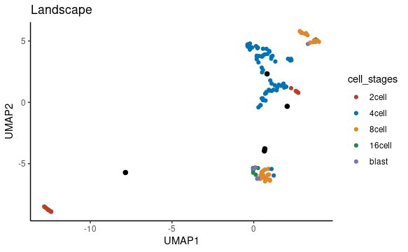

The landscape of Goolam data set using UMAP and colored by ground truth development stages.

```r
set.seed(1)
cell_stages <- factor(label, levels = stages)
label <- as.numeric(factor(label, levels = stages))
latent <- cbind(umap.res, label) %>% as.data.frame()

# Calculate cluster centroid and create dataframe saving start and end points.
clus_center <- lapply(1:length(unique(label)), function(cl) colMeans(latent[label == cl, ])) %>%
  do.call(what = rbind)
colnames(clus_center) <- c("x", "y", "cluster_id")

figure <- ggplot2::ggplot(latent, ggplot2::aes(x = V1, y = V2, color = cell_stages)) +
  ggplot2::geom_point() +
  # Plot the centroid
  ggplot2::geom_point(data = as.data.frame(clus_center), ggplot2::aes(x = x, y = y), color = 'black', size = 2) +
  ggplot2::labs(x = paste0("UMAP1"), y = paste0("UMAP2"), title = paste("Landscape")) +
  ggplot2::theme_classic() +
  ggplot2::scale_color_manual(values = cols) +
  # annotate(geom = "table", x=min(tsne_original$V1),y=min(tsne_original$V2), label = silhou)+
  # scale_color_npg()+
  ggsci::scale_fill_npg() +
  ggplot2::theme(
    legend.position = "right"
  )
figure
```

Second, we color the landscape of goolam data set with the scTEP’s output pseudotime.

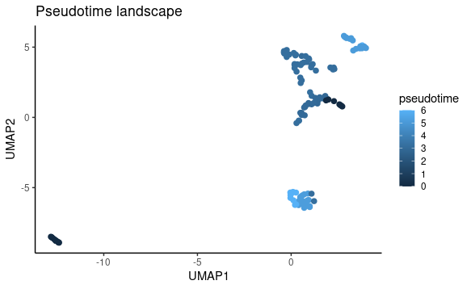

The landscape of goolam data set and colored by the scTEP’s output pseudotime.

```r
latent <- uwot::umap(scDHA_res$latent) %>% as.data.frame()
pseudotime = out$pseudotime
# Calculate cluster centroid and create dataframe saving start and end points.
figure <- ggplot2::ggplot(latent, ggplot2::aes(x = V1, y = V2)) +
  ggplot2::labs(x = paste0("UMAP1"), y = paste0("UMAP2"), title = paste("Pseudotime landscape")) +
  ggplot2::geom_point(ggplot2::aes(color = pseudotime), size = 2) +
  ggplot2::theme_classic() +
  ggplot2::theme(
    legend.position = "right",
    plot.title = ggplot2::element_text(),
    axis.text = ggplot2::element_text(),
    axis.title = ggplot2::element_text(),
    legend.key.size = ggplot2::unit(1, "cm"), legend.text = ggplot2::element_text(), legend.title = ggplot2::element_text)
figure
```

Third, we visualization of scTEP’s output trajectory. An imperfection is that scTEP generates an extra branch.

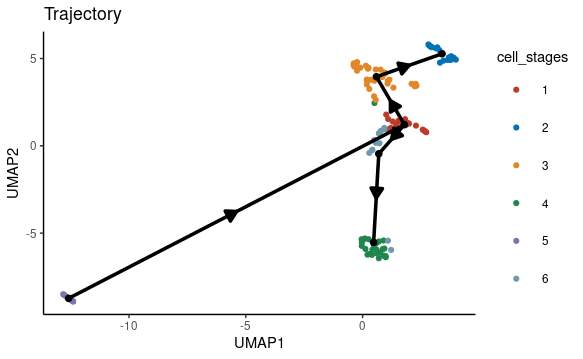

The scTEP’s output trajectory visualized in reduced dimensional space using UMAP.

```r
# Draw trajectory plot
edge_nodes <- out$milestone_network[, 1:2] %>% as.data.frame()
cluster = out$cluster
latent <- cbind(umap.res, cluster) %>% as.data.frame()
cell_stages <- factor(cluster)

# Calculate cluster centroid and create dataframe saving start and end points.
clus_center <- lapply(1:length(unique(cluster)), function(cl) colMeans(latent[which(cluster == cl), ])) %>%
  do.call(what = rbind)

colnames(clus_center) <- c("x", "y", "cluster_id")
clulines <- NULL
for (edge_index in 1:nrow(edge_nodes)) {
  start_cluster <- edge_nodes[edge_index, 1] %>% as.numeric()
  end_cluster <- edge_nodes[edge_index, 2] %>% as.numeric()
  temp_points <- c(
    clus_center[, "x"][start_cluster], clus_center[, "y"][start_cluster],
    clus_center[, "x"][end_cluster], clus_center[, "y"][end_cluster]
  )
  clulines <- rbind(clulines, temp_points)
}
colnames(clulines) <- c("x", "y", "xend", "yend")
clulines <- as.data.frame(clulines)
clulines$x.mid <- (clulines$x + clulines$xend) / 2
clulines$y.mid <- (clulines$y + clulines$yend) / 2


figure <- ggplot2::ggplot(latent, ggplot2::aes(x = V1, y = V2, color = cell_stages)) +
  ggplot2::geom_point() +
  # Plot the centroid
  ggplot2::geom_point(data = as.data.frame(clus_center), ggplot2::aes(x = x, y = y), color = "black", size = 2) +
  ggplot2::labs(x = paste0("UMAP1"), y = paste0("UMAP2"), title = paste("Trajectory")) +
  # Add Sting to the figure
  ggplot2::geom_segment(ggplot2::aes_string(x = "x.mid", xend = "xend", y = "y.mid", yend = "yend", size = NULL),
                        data = clulines, color = "black", size = 1.25
  ) +
  # Add arrow to string
  ggplot2::geom_segment(
    arrow = ggplot2::arrow(length = ggplot2::unit(0.3, "cm"), type = "closed", ends = "last"),
    ggplot2::aes_string(x = "x", xend = "x.mid", y = "y", yend = "y.mid", size = NULL),
    data = clulines, color = "black", size = 1.25
  ) +
  ggplot2::theme_classic() +
  ggplot2::scale_color_manual(values = cols) +
  ggsci::scale_fill_npg() +
  ggplot2::theme(
    legend.position = "right",
    plot.title = ggplot2::element_text(),
    axis.text = ggplot2::element_text(),
    axis.title = ggplot2::element_text(),
    legend.key.size = ggplot2::unit(1, "cm"), legend.text = ggplot2::element_text(), legend.title = ggplot2::element_text()
  )
figure
```

The visualization of scTEP’s pseudotime. The x-axis is the pseudotime, the y-axis is the cell’s true type. The pseudotime of *2cell*, *4cell*, and *8cell* are consistent with ground truth. The pseudotime of *16cell*, and *blast* are the same, which is different from the groud truth.

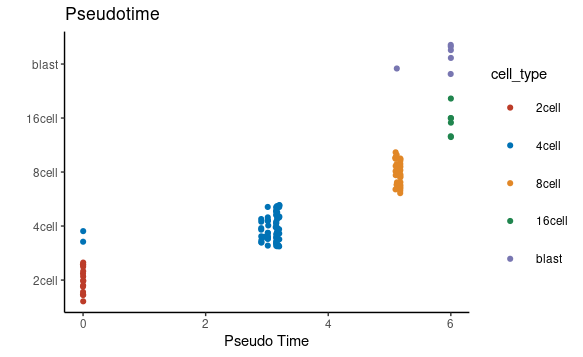

The scTEP’s output pseudotime compare with ground truth development stages.

```r
#Draw_dev_pseudotime <- function(dataset, label, cell.stages, pseudotime, r, cols) {
raw <- goolam$label %>% as.character() %>% as.data.frame()
raw$time <- pseudotime
raw[, 1] <- factor(raw[, 1], levels = stages)
colnames(raw) <- c("cell_type","pseudotime")
figure <- ggplot2::ggplot(raw, ggplot2::aes(y = cell_type, x = pseudotime, color = cell_type)) +
  ggplot2::geom_jitter() +
  ggplot2::labs(x = "Pseudo Time", y = "", title = paste0("Pseudotime")) +
  ggplot2::scale_color_manual(values = cols) +
  ggplot2::theme_classic() +
  ggplot2::theme(
    legend.position = "right",
    plot.title = ggplot2::element_text(size = 20),
    axis.text = ggplot2::element_text(size = 20),
    axis.title = ggplot2::element_text(size = 20),
    legend.key.size = ggplot2::unit(1, "cm"), legend.text = ggplot2::element_text(size = 20), legend.title = ggplot2::element_text(size = 20),
  )
figure
```

# Reference

Goolam, Mubeen, Antonio Scialdone, Sarah JL Graham, Iain C Macaulay, Agnieszka Jedrusik, Anna Hupalowska, Thierry Voet, John C Marioni, and Magdalena Zernicka-Goetz. 2016. “Heterogeneity in Oct4 and Sox2 Targets Biases Cell Fate in 4-Cell Mouse Embryos.” *Cell* 165 (1): 61–74.

Kanehisa, Minoru, Miho Furumichi, Yoko Sato, Mari Ishiguro-Watanabe, and Mao Tanabe. 2021. “KEGG: Integrating Viruses and Cellular Organisms.” *Nucleic Acids Research* 49 (D1): D545–D551.

Tran, Duc, Hung Nguyen, Bang Tran, Carlo La Vecchia, Hung N Luu, and Tin Nguyen. 2021. “Fast and Precise Single-Cell Data Analysis Using a Hierarchical Autoencoder.” *Nature Communications* 12 (1): 1–10.